# Wrangle and Analyze Data Project

## Gathering Data

### 1. WeRateDogs Twitter archive

```python
import pandas as pd
import numpy as np
import requests
import json
import pprint
from datetime import datetime
import matplotlib.pyplot as plt
%matplotlib inline
```

```python
# The file "twitter-archive-enhanced.csv" is already provided, therefore it can directly be read into the dataframe
archive_df = pd.read_csv('twitter-archive-enhanced.csv')
archive_df.head()
```

|  | tweet_id | in_reply_to_status_id | in_reply_to_user_id | timestamp | source | text | retweeted_status_id | retweeted_status_user_id | retweeted_status_timestamp | expanded_urls | rating_numerator | rating_denominator | name | doggo | floofer | pupper | puppo |
| --- | --- | --- | --- | --- | --- | --- | --- | --- | --- | --- | --- | --- | --- | --- | --- | --- | --- |
| 0 | 892420643555336193 | NaN | NaN | 2017-08-01 16:23:56 +0000 | <a href="http://twitter.com/download/iphone" r... | This is Phineas. He's a mystical boy. Only eve... | NaN | NaN | NaN | https://twitter.com/dog_rates/status/892420643... | 13 | 10 | Phineas | None | None | None | None |
| 1 | 892177421306343426 | NaN | NaN | 2017-08-01 00:17:27 +0000 | <a href="http://twitter.com/download/iphone" r... | This is Tilly. She's just checking pup on you.... | NaN | NaN | NaN | https://twitter.com/dog_rates/status/892177421... | 13 | 10 | Tilly | None | None | None | None |
| 2 | 891815181378084864 | NaN | NaN | 2017-07-31 00:18:03 +0000 | <a href="http://twitter.com/download/iphone" r... | This is Archie. He is a rare Norwegian Pouncin... | NaN | NaN | NaN | https://twitter.com/dog_rates/status/891815181... | 12 | 10 | Archie | None | None | None | None |
| 3 | 891689557279858688 | NaN | NaN | 2017-07-30 15:58:51 +0000 | <a href="http://twitter.com/download/iphone" r... | This is Darla. She commenced a snooze mid meal... | NaN | NaN | NaN | https://twitter.com/dog_rates/status/891689557... | 13 | 10 | Darla | None | None | None | None |
| 4 | 891327558926688256 | NaN | NaN | 2017-07-29 16:00:24 +0000 | <a href="http://twitter.com/download/iphone" r... | This is Franklin. He would like you to stop ca... | NaN | NaN | NaN | https://twitter.com/dog_rates/status/891327558... | 12 | 10 | Franklin | None | None | None | None |

### 2. Image predictions file

```python
# Programmatically downloading the "image_predictions.tsv" file using Requests library
response = requests.get('https://d17h27t6h515a5.cloudfront.net/topher/2017/August/599fd2ad_image-predictions/image-predictions.tsv')
response
```

```
<Response [200]>
```

```python
with open('image-predictions.tsv','w+') as file:
    file.write(response.text)
```

```python
predictions_df = pd.read_csv('image-predictions.tsv',sep='\t')
predictions_df.head()
```

|  | tweet_id | jpg_url | img_num | p1 | p1_conf | p1_dog | p2 | p2_conf | p2_dog | p3 | p3_conf | p3_dog |
| --- | --- | --- | --- | --- | --- | --- | --- | --- | --- | --- | --- | --- |
| 0 | 666020888022790149 | https://pbs.twimg.com/media/CT4udn0WwAA0aMy.jpg | 1 | Welsh_springer_spaniel | 0.465074 | True | collie | 0.156665 | True | Shetland_sheepdog | 0.061428 | True |
| 1 | 666029285002620928 | https://pbs.twimg.com/media/CT42GRgUYAA5iDo.jpg | 1 | redbone | 0.506826 | True | miniature_pinscher | 0.074192 | True | Rhodesian_ridgeback | 0.072010 | True |
| 2 | 666033412701032449 | https://pbs.twimg.com/media/CT4521TWwAEvMyu.jpg | 1 | German_shepherd | 0.596461 | True | malinois | 0.138584 | True | bloodhound | 0.116197 | True |
| 3 | 666044226329800704 | https://pbs.twimg.com/media/CT5Dr8HUEAA-lEu.jpg | 1 | Rhodesian_ridgeback | 0.408143 | True | redbone | 0.360687 | True | miniature_pinscher | 0.222752 | True |
| 4 | 666049248165822465 | https://pbs.twimg.com/media/CT5IQmsXIAAKY4A.jpg | 1 | miniature_pinscher | 0.560311 | True | Rottweiler | 0.243682 | True | Doberman | 0.154629 | True |

### 3. Twitter API data

```python
#I haven't created a twitter account therefore, reading in the data from tweet_json.txt and inspecting a line
with open('tweet-json.txt') as f:
    line = f.readline()
    tweet = json.loads(line)
    pprint.pprint(tweet)
```

```
{'contributors': None,
 'coordinates': None,
 'created_at': 'Tue Aug 01 16:23:56 +0000 2017',
 'display_text_range': [0, 85],
 'entities': {'hashtags': [],
              'media': [{'display_url': 'pic.twitter.com/MgUWQ76dJU',
                         'expanded_url': 'https://twitter.com/dog_rates/status/892420643555336193/photo/1',
                         'id': 892420639486877696,
                         'id_str': '892420639486877696',
                         'indices': [86, 109],
                         'media_url': 'http://pbs.twimg.com/media/DGKD1-bXoAAIAUK.jpg',
                         'media_url_https': 'https://pbs.twimg.com/media/DGKD1-bXoAAIAUK.jpg',
                         'sizes': {'large': {'h': 528,
                                             'resize': 'fit',
                                             'w': 540},
                                   'medium': {'h': 528,
                                              'resize': 'fit',
                                              'w': 540},
                                   'small': {'h': 528,
                                             'resize': 'fit',
                                             'w': 540},
                                   'thumb': {'h': 150,
                                             'resize': 'crop',
                                             'w': 150}},
                         'type': 'photo',
                         'url': 'https://t.co/MgUWQ76dJU'}],
              'symbols': [],
              'urls': [],
              'user_mentions': []},
 'extended_entities': {'media': [{'display_url': 'pic.twitter.com/MgUWQ76dJU',
                                  'expanded_url': 'https://twitter.com/dog_rates/status/892420643555336193/photo/1',
                                  'id': 892420639486877696,
                                  'id_str': '892420639486877696',
                                  'indices': [86, 109],
                                  'media_url': 'http://pbs.twimg.com/media/DGKD1-bXoAAIAUK.jpg',
                                  'media_url_https': 'https://pbs.twimg.com/media/DGKD1-bXoAAIAUK.jpg',
                                  'sizes': {'large': {'h': 528,
                                                      'resize': 'fit',
                                                      'w': 540},
                                            'medium': {'h': 528,
```

[output cut: 66 more lines]

```
          'profile_image_url': 'http://pbs.twimg.com/profile_images/861415328504569856/R2xOOfwe_normal.jpg',
          'profile_image_url_https': 'https://pbs.twimg.com/profile_images/861415328504569856/R2xOOfwe_normal.jpg',
          'profile_link_color': 'F5ABB5',
          'profile_sidebar_border_color': '000000',
          'profile_sidebar_fill_color': '000000',
          'profile_text_color': '000000',
          'profile_use_background_image': False,
          'protected': False,
          'screen_name': 'dog_rates',
          'statuses_count': 5288,
          'time_zone': None,
          'translator_type': 'none',
          'url': 'https://t.co/N7sNNHAEXS',
          'utc_offset': None,
          'verified': True}}
```

```python
# At minimum, we need the tweet ID, retweet count and favorite count. I don't see any additional fields that could help us with the analysis, therefore not storing them into the dataframe
tweet_id = []
retweet_count = []
favorite_count = []
with open('tweet-json.txt') as f:
    line = f.readline()
    while(line):
        tweet = json.loads(line)
        tweet_id.append(tweet['id'])
        retweet_count.append(tweet['retweet_count'])
        favorite_count.append(tweet['favorite_count'])
        line = f.readline()

tweets_json_df = pd.DataFrame({'tweet_id':tweet_id,'retweet_count':retweet_count,'favorite_count':favorite_count})
tweets_json_df.head()
```

|  | tweet_id | retweet_count | favorite_count |
| --- | --- | --- | --- |
| 0 | 892420643555336193 | 8853 | 39467 |
| 1 | 892177421306343426 | 6514 | 33819 |
| 2 | 891815181378084864 | 4328 | 25461 |
| 3 | 891689557279858688 | 8964 | 42908 |
| 4 | 891327558926688256 | 9774 | 41048 |

## Analyzing the Data

```python
archive_df.head()
```

|  | tweet_id | in_reply_to_status_id | in_reply_to_user_id | timestamp | source | text | retweeted_status_id | retweeted_status_user_id | retweeted_status_timestamp | expanded_urls | rating_numerator | rating_denominator | name | doggo | floofer | pupper | puppo |
| --- | --- | --- | --- | --- | --- | --- | --- | --- | --- | --- | --- | --- | --- | --- | --- | --- | --- |
| 0 | 892420643555336193 | NaN | NaN | 2017-08-01 16:23:56 +0000 | <a href="http://twitter.com/download/iphone" r... | This is Phineas. He's a mystical boy. Only eve... | NaN | NaN | NaN | https://twitter.com/dog_rates/status/892420643... | 13 | 10 | Phineas | None | None | None | None |
| 1 | 892177421306343426 | NaN | NaN | 2017-08-01 00:17:27 +0000 | <a href="http://twitter.com/download/iphone" r... | This is Tilly. She's just checking pup on you.... | NaN | NaN | NaN | https://twitter.com/dog_rates/status/892177421... | 13 | 10 | Tilly | None | None | None | None |
| 2 | 891815181378084864 | NaN | NaN | 2017-07-31 00:18:03 +0000 | <a href="http://twitter.com/download/iphone" r... | This is Archie. He is a rare Norwegian Pouncin... | NaN | NaN | NaN | https://twitter.com/dog_rates/status/891815181... | 12 | 10 | Archie | None | None | None | None |
| 3 | 891689557279858688 | NaN | NaN | 2017-07-30 15:58:51 +0000 | <a href="http://twitter.com/download/iphone" r... | This is Darla. She commenced a snooze mid meal... | NaN | NaN | NaN | https://twitter.com/dog_rates/status/891689557... | 13 | 10 | Darla | None | None | None | None |
| 4 | 891327558926688256 | NaN | NaN | 2017-07-29 16:00:24 +0000 | <a href="http://twitter.com/download/iphone" r... | This is Franklin. He would like you to stop ca... | NaN | NaN | NaN | https://twitter.com/dog_rates/status/891327558... | 12 | 10 | Franklin | None | None | None | None |

> **The first 5 rows have 'None' set for all columns corresponding to the dog stage i.e. doggo, floofer, pupper and puppo. Need to verify how many more rows don't have the stage set.**

```python
archive_df[(archive_df.doggo=='None')&(archive_df.floofer=='None')&(archive_df.pupper=='None')&(archive_df.puppo=='None')].shape
```

```
(1976, 17)
```

> **There are 1976 rows which don't have the dog stage set.**

```python
# Checking to see if the text can be parsed to get the stage the dog is in. However, the text doesn't seem to contain this info.
print(archive_df[(archive_df.doggo=='None')&(archive_df.floofer=='None')&(archive_df.pupper=='None')&(archive_df.puppo=='None')].iloc[1].text)
print('\n\n')
print(archive_df[(archive_df.doggo=='None')&(archive_df.floofer=='None')&(archive_df.pupper=='None')&(archive_df.puppo=='None')].iloc[2].text)
```

```
This is Tilly. She's just checking pup on you. Hopes you're doing ok. If not, she's available for pats, snugs, boops, the whole bit. 13/10 https://t.co/0Xxu71qeIV



This is Archie. He is a rare Norwegian Pouncing Corgo. Lives in the tall grass. You never know when one may strike. 12/10 https://t.co/wUnZnhtVJB
```

```python
archive_df.info()
```

```
<class 'pandas.core.frame.DataFrame'>
RangeIndex: 2356 entries, 0 to 2355
Data columns (total 17 columns):
tweet_id                      2356 non-null int64
in_reply_to_status_id         78 non-null float64
in_reply_to_user_id           78 non-null float64
timestamp                     2356 non-null object
source                        2356 non-null object
text                          2356 non-null object
retweeted_status_id           181 non-null float64
retweeted_status_user_id      181 non-null float64
retweeted_status_timestamp    181 non-null object
expanded_urls                 2297 non-null object
rating_numerator              2356 non-null int64
rating_denominator            2356 non-null int64
name                          2356 non-null object
doggo                         2356 non-null object
floofer                       2356 non-null object
pupper                        2356 non-null object
puppo                         2356 non-null object
dtypes: float64(4), int64(3), object(10)
memory usage: 313.0+ KB
```

> **Looks like there are 181 retweets and 78 replies (original tweets = 2356-181-78 = 2097)**

> **The 'timestamp' column is of type object i.e. string instead of datetime object.**

```python
archive_df.describe()
```

|  | tweet_id | in_reply_to_status_id | in_reply_to_user_id | retweeted_status_id | retweeted_status_user_id | rating_numerator | rating_denominator |
| --- | --- | --- | --- | --- | --- | --- | --- |
| count | 2.356000e+03 | 7.800000e+01 | 7.800000e+01 | 1.810000e+02 | 1.810000e+02 | 2356.000000 | 2356.000000 |
| mean | 7.427716e+17 | 7.455079e+17 | 2.014171e+16 | 7.720400e+17 | 1.241698e+16 | 13.126486 | 10.455433 |
| std | 6.856705e+16 | 7.582492e+16 | 1.252797e+17 | 6.236928e+16 | 9.599254e+16 | 45.876648 | 6.745237 |
| min | 6.660209e+17 | 6.658147e+17 | 1.185634e+07 | 6.661041e+17 | 7.832140e+05 | 0.000000 | 0.000000 |
| 25% | 6.783989e+17 | 6.757419e+17 | 3.086374e+08 | 7.186315e+17 | 4.196984e+09 | 10.000000 | 10.000000 |
| 50% | 7.196279e+17 | 7.038708e+17 | 4.196984e+09 | 7.804657e+17 | 4.196984e+09 | 11.000000 | 10.000000 |
| 75% | 7.993373e+17 | 8.257804e+17 | 4.196984e+09 | 8.203146e+17 | 4.196984e+09 | 12.000000 | 10.000000 |
| max | 8.924206e+17 | 8.862664e+17 | 8.405479e+17 | 8.874740e+17 | 7.874618e+17 | 1776.000000 | 170.000000 |

> **The minimum values for both 'rating_numerator' and 'rating_denominator' seem to be 0 while the maximum values are 1776 and 170 respectively. According to the unique rating system of WeRateDogs, the rating numerators are expected to be greater than the denominators. However, these values seem to be too high.**

```python
# Looking at the numerators and denominators in the ratings for only original tweets
original_tweets = archive_df[archive_df['retweeted_status_id'].isna() & archive_df['in_reply_to_status_id'].isna()]
original_tweets.info()
```

```
<class 'pandas.core.frame.DataFrame'>
Int64Index: 2097 entries, 0 to 2355
Data columns (total 17 columns):
tweet_id                      2097 non-null int64
in_reply_to_status_id         0 non-null float64
in_reply_to_user_id           0 non-null float64
timestamp                     2097 non-null object
source                        2097 non-null object
text                          2097 non-null object
retweeted_status_id           0 non-null float64
retweeted_status_user_id      0 non-null float64
retweeted_status_timestamp    0 non-null object
expanded_urls                 2094 non-null object
rating_numerator              2097 non-null int64
rating_denominator            2097 non-null int64
name                          2097 non-null object
doggo                         2097 non-null object
floofer                       2097 non-null object
pupper                        2097 non-null object
puppo                         2097 non-null object
dtypes: float64(4), int64(3), object(10)
memory usage: 294.9+ KB
```

```python
original_tweets.rating_numerator.value_counts()
```

```
12      486
10      436
11      413
13      287
9       153
8        98
7        52
14       38
5        34
6        32
3        19
4        16
2         9
1         5
26        1
```

[output cut: 19 more lines]

> **The ratings between 10 and 14 seem reasonable. The values greater than 14 such as 75, 99 etc. would've to be manually verified and set correctly. Values such as 1 and 0 seem too low, checking a couple samples to see if they are right.**

```python
low_numerator_indices = list(original_tweets[(original_tweets['rating_numerator']==1) | (original_tweets['rating_numerator']==0)].index)
low_numerator_indices
```

```
[315, 1869, 2091, 2261, 2335, 2338]
```

```python
archive_df.iloc[low_numerator_indices]
```

|  | tweet_id | in_reply_to_status_id | in_reply_to_user_id | timestamp | source | text | retweeted_status_id | retweeted_status_user_id | retweeted_status_timestamp | expanded_urls | rating_numerator | rating_denominator | name | doggo | floofer | pupper | puppo |
| --- | --- | --- | --- | --- | --- | --- | --- | --- | --- | --- | --- | --- | --- | --- | --- | --- | --- |
| 315 | 835152434251116546 | NaN | NaN | 2017-02-24 15:40:31 +0000 | <a href="http://twitter.com/download/iphone" r... | When you're so blinded by your systematic plag... | NaN | NaN | NaN | https://twitter.com/dog_rates/status/835152434... | 0 | 10 | None | None | None | None | None |
| 1869 | 675153376133427200 | NaN | NaN | 2015-12-11 03:21:23 +0000 | <a href="http://twitter.com/download/iphone" r... | What kind of person sends in a picture without... | NaN | NaN | NaN | https://twitter.com/dog_rates/status/675153376... | 1 | 10 | None | None | None | None | None |
| 2091 | 670783437142401025 | NaN | NaN | 2015-11-29 01:56:48 +0000 | <a href="http://twitter.com/download/iphone" r... | Flamboyant pup here. Probably poisonous. Won't... | NaN | NaN | NaN | https://twitter.com/dog_rates/status/670783437... | 1 | 10 | None | None | None | None | None |
| 2261 | 667549055577362432 | NaN | NaN | 2015-11-20 03:44:31 +0000 | <a href="http://twitter.com" rel="nofollow">Tw... | Never seen dog like this. Breathes heavy. Tilt... | NaN | NaN | NaN | https://twitter.com/dog_rates/status/667549055... | 1 | 10 | None | None | None | None | None |
| 2335 | 666287406224695296 | NaN | NaN | 2015-11-16 16:11:11 +0000 | <a href="http://twitter.com/download/iphone" r... | This is an Albanian 3 1/2 legged Episcopalian... | NaN | NaN | NaN | https://twitter.com/dog_rates/status/666287406... | 1 | 2 | an | None | None | None | None |
| 2338 | 666104133288665088 | NaN | NaN | 2015-11-16 04:02:55 +0000 | <a href="http://twitter.com/download/iphone" r... | Not familiar with this breed. No tail (weird).... | NaN | NaN | NaN | https://twitter.com/dog_rates/status/666104133... | 1 | 10 | None | None | None | None | None |

```python
for index in low_numerator_indices:
    print('\n'+ str(index) + "   " + str(archive_df.iloc[index].rating_numerator)+"   "+archive_df.iloc[index].text)
```

```
315   0   When you're so blinded by your systematic plagiarism that you forget what day it is. 0/10 https://t.co/YbEJPkg4Ag

1869   1   What kind of person sends in a picture without a dog in it? 1/10 just because that's a nice table https://t.co/RDXCfk8hK0

2091   1   Flamboyant pup here. Probably poisonous. Won't eat kibble. Doesn't bark. Slow af. Petting doesn't look fun. 1/10 https://t.co/jxukeh2BeO

2261   1   Never seen dog like this. Breathes heavy. Tilts head in a pattern. No bark. Shitty at fetch. Not even cordless. 1/10 https://t.co/i9iSGNn3fx

2335   1   This is an Albanian 3 1/2 legged  Episcopalian. Loves well-polished hardwood flooring. Penis on the collar. 9/10 https://t.co/d9NcXFKwLv

2338   1   Not familiar with this breed. No tail (weird). Only 2 legs. Doesn't bark. Surprisingly quick. Shits eggs. 1/10 https://t.co/Asgdc6kuLX
```

> **The rating_numerator for index 2335 should be 9 instead of 1. The others seem to be right. It was mentioned that the text was parsed and the ratings were obtained. It is possible that the text was pattern matched for x/y where x and y are the numerator and denominators of the rating. However, in this case, the string "3 1/2 legged" might have matched the pattern causing the error. Need to check if there are more rows where there are multiple / s included in the text that could've caused an error**

```python
high_numerator_indices = list(original_tweets[(original_tweets['rating_numerator']>14)].index)
print(high_numerator_indices)
archive_df.iloc[high_numerator_indices]
```

```
[433, 516, 695, 763, 902, 979, 1120, 1202, 1228, 1254, 1274, 1351, 1433, 1635, 1712, 1779, 1843, 2074]
```

|  | tweet_id | in_reply_to_status_id | in_reply_to_user_id | timestamp | source | text | retweeted_status_id | retweeted_status_user_id | retweeted_status_timestamp | expanded_urls | rating_numerator | rating_denominator | name | doggo | floofer | pupper | puppo |
| --- | --- | --- | --- | --- | --- | --- | --- | --- | --- | --- | --- | --- | --- | --- | --- | --- | --- |
| 433 | 820690176645140481 | NaN | NaN | 2017-01-15 17:52:40 +0000 | <a href="http://twitter.com/download/iphone" r... | The floofs have been released I repeat the flo... | NaN | NaN | NaN | https://twitter.com/dog_rates/status/820690176... | 84 | 70 | None | None | None | None | None |
| 516 | 810984652412424192 | NaN | NaN | 2016-12-19 23:06:23 +0000 | <a href="http://twitter.com/download/iphone" r... | Meet Sam. She smiles 24/7 &amp; secretly aspir... | NaN | NaN | NaN | https://www.gofundme.com/sams-smile,https://tw... | 24 | 7 | Sam | None | None | None | None |
| 695 | 786709082849828864 | NaN | NaN | 2016-10-13 23:23:56 +0000 | <a href="http://twitter.com/download/iphone" r... | This is Logan, the Chow who lived. He solemnly... | NaN | NaN | NaN | https://twitter.com/dog_rates/status/786709082... | 75 | 10 | Logan | None | None | None | None |
| 763 | 778027034220126208 | NaN | NaN | 2016-09-20 00:24:34 +0000 | <a href="http://twitter.com/download/iphone" r... | This is Sophie. She's a Jubilant Bush Pupper. ... | NaN | NaN | NaN | https://twitter.com/dog_rates/status/778027034... | 27 | 10 | Sophie | None | None | pupper | None |
| 902 | 758467244762497024 | NaN | NaN | 2016-07-28 01:00:57 +0000 | <a href="http://twitter.com/download/iphone" r... | Why does this never happen at my front door...... | NaN | NaN | NaN | https://twitter.com/dog_rates/status/758467244... | 165 | 150 | None | None | None | None | None |
| 979 | 749981277374128128 | NaN | NaN | 2016-07-04 15:00:45 +0000 | <a href="https://about.twitter.com/products/tw... | This is Atticus. He's quite simply America af.... | NaN | NaN | NaN | https://twitter.com/dog_rates/status/749981277... | 1776 | 10 | Atticus | None | None | None | None |
| 1120 | 731156023742988288 | NaN | NaN | 2016-05-13 16:15:54 +0000 | <a href="http://twitter.com/download/iphone" r... | Say hello to this unbelievably well behaved sq... | NaN | NaN | NaN | https://twitter.com/dog_rates/status/731156023... | 204 | 170 | this | None | None | None | None |
| 1202 | 716439118184652801 | NaN | NaN | 2016-04-03 01:36:11 +0000 | <a href="http://twitter.com/download/iphone" r... | This is Bluebert. He just saw that both #Final... | NaN | NaN | NaN | https://twitter.com/dog_rates/status/716439118... | 50 | 50 | Bluebert | None | None | None | None |
| 1228 | 713900603437621249 | NaN | NaN | 2016-03-27 01:29:02 +0000 | <a href="http://twitter.com/download/iphone" r... | Happy Saturday here's 9 puppers on a bench. 99... | NaN | NaN | NaN | https://twitter.com/dog_rates/status/713900603... | 99 | 90 | None | None | None | None | None |
| 1254 | 710658690886586372 | NaN | NaN | 2016-03-18 02:46:49 +0000 | <a href="http://twitter.com/download/iphone" r... | Here's a brigade of puppers. All look very pre... | NaN | NaN | NaN | https://twitter.com/dog_rates/status/710658690... | 80 | 80 | None | None | None | None | None |
| 1274 | 709198395643068416 | NaN | NaN | 2016-03-14 02:04:08 +0000 | <a href="http://twitter.com/download/iphone" r... | From left to right:\nCletus, Jerome, Alejandro... | NaN | NaN | NaN | https://twitter.com/dog_rates/status/709198395... | 45 | 50 | None | None | None | None | None |
| 1351 | 704054845121142784 | NaN | NaN | 2016-02-28 21:25:30 +0000 | <a href="http://twitter.com/download/iphone" r... | Here is a whole flock of puppers. 60/50 I'll ... | NaN | NaN | NaN | https://twitter.com/dog_rates/status/704054845... | 60 | 50 | a | None | None | None | None |
| 1433 | 697463031882764288 | NaN | NaN | 2016-02-10 16:51:59 +0000 | <a href="http://twitter.com/download/iphone" r... | Happy Wednesday here's a bucket of pups. 44/40... | NaN | NaN | NaN | https://twitter.com/dog_rates/status/697463031... | 44 | 40 | None | None | None | None | None |
| 1635 | 684222868335505415 | NaN | NaN | 2016-01-05 04:00:18 +0000 | <a href="http://twitter.com/download/iphone" r... | Someone help the girl is being mugged. Several... | NaN | NaN | NaN | https://twitter.com/dog_rates/status/684222868... | 121 | 110 | None | None | None | None | None |
| 1712 | 680494726643068929 | NaN | NaN | 2015-12-25 21:06:00 +0000 | <a href="http://twitter.com/download/iphone" r... | Here we have uncovered an entire battalion of ... | NaN | NaN | NaN | https://twitter.com/dog_rates/status/680494726... | 26 | 10 | None | None | None | None | None |
| 1779 | 677716515794329600 | NaN | NaN | 2015-12-18 05:06:23 +0000 | <a href="http://twitter.com/download/iphone" r... | IT'S PUPPERGEDDON. Total of 144/120 ...I think... | NaN | NaN | NaN | https://twitter.com/dog_rates/status/677716515... | 144 | 120 | None | None | None | None | None |
| 1843 | 675853064436391936 | NaN | NaN | 2015-12-13 01:41:41 +0000 | <a href="http://twitter.com/download/iphone" r... | Here we have an entire platoon of puppers. Tot... | NaN | NaN | NaN | https://twitter.com/dog_rates/status/675853064... | 88 | 80 | None | None | None | None | None |
| 2074 | 670842764863651840 | NaN | NaN | 2015-11-29 05:52:33 +0000 | <a href="http://twitter.com/download/iphone" r... | After so many requests... here you go.\n\nGood... | NaN | NaN | NaN | https://twitter.com/dog_rates/status/670842764... | 420 | 10 | None | None | None | None | None |

```python
for index in high_numerator_indices:
    print('\n'+ str(index) + "   " + str(archive_df.iloc[index].rating_numerator)+"   "+archive_df.iloc[index].text)
```

```
433   84   The floofs have been released I repeat the floofs have been released. 84/70 https://t.co/NIYC820tmd

516   24   Meet Sam. She smiles 24/7 &amp; secretly aspires to be a reindeer.
Keep Sam smiling by clicking and sharing this link:
https://t.co/98tB8y7y7t https://t.co/LouL5vdvxx

695   75   This is Logan, the Chow who lived. He solemnly swears he's up to lots of good. H*ckin magical af 9.75/10 https://t.co/yBO5wuqaPS

763   27   This is Sophie. She's a Jubilant Bush Pupper. Super h*ckin rare. Appears at random just to smile at the locals. 11.27/10 would smile back https://t.co/QFaUiIHxHq

902   165   Why does this never happen at my front door... 165/150 https://t.co/HmwrdfEfUE

979   1776   This is Atticus. He's quite simply America af. 1776/10 https://t.co/GRXwMxLBkh

1120   204   Say hello to this unbelievably well behaved squad of doggos. 204/170 would try to pet all at once https://t.co/yGQI3He3xv

1202   50   This is Bluebert. He just saw that both #FinalFur match ups are split 50/50. Amazed af. 11/10 https://t.co/Kky1DPG4iq

1228   99   Happy Saturday here's 9 puppers on a bench. 99/90 good work everybody https://t.co/mpvaVxKmc1

1254   80   Here's a brigade of puppers. All look very prepared for whatever happens next. 80/80 https://t.co/0eb7R1Om12

1274   45   From left to right:
Cletus, Jerome, Alejandro, Burp, &amp; Titson
None know where camera is. 45/50 would hug all at once https://t.co/sedre1ivTK

1351   60   Here is a whole flock of puppers.  60/50 I'll take the lot https://t.co/9dpcw6MdWa

1433   44   Happy Wednesday here's a bucket of pups. 44/40 would pet all at once https://t.co/HppvrYuamZ

1635   121   Someone help the girl is being mugged. Several are distracting her while two steal her shoes. Clever puppers 121/110 https://t.co/1zfnTJLt55

1712   26   Here we have uncovered an entire battalion of holiday puppers. Average of 11.26/10 https://t.co/eNm2S6p9BD

1779   144   IT'S PUPPERGEDDON. Total of 144/120 ...I think https://t.co/ZanVtAtvIq

1843   88   Here we have an entire platoon of puppers. Total score: 88/80 would pet all at once https://t.co/y93p6FLvVw

2074   420   After so many requests... here you go.

Good dogg. 420/10 https://t.co/yfAAo1gdeY
```

> **There is no rating for the row with index 516. The rating for row with index 695 should be 9.75 instead of 75. It looks like the numerator ratings can be "float" as well. However, the current datatype is "int" for numerator ratings. Index 763 value should be 11.27 instead of 27. Index 1202 the rating is 11/10 instead of 50/50. Index 1712 value is 11.26 instead of 26.**

```python
original_tweets.rating_denominator.value_counts()
```

```
10     2080
50        3
11        2
80        2
7         1
170       1
150       1
120       1
110       1
90        1
70        1
40        1
20        1
2         1
Name: rating_denominator, dtype: int64
```

> **Similarly, manually checking the denominators of the ratings which are greater than 10 to understand if there is a data entry error.**

```python
denominator_indices = list(original_tweets[(original_tweets['rating_denominator']!=10)].index)
print(denominator_indices)
archive_df.iloc[denominator_indices]
```

```
[433, 516, 902, 1068, 1120, 1165, 1202, 1228, 1254, 1274, 1351, 1433, 1635, 1662, 1779, 1843, 2335]
```

|  | tweet_id | in_reply_to_status_id | in_reply_to_user_id | timestamp | source | text | retweeted_status_id | retweeted_status_user_id | retweeted_status_timestamp | expanded_urls | rating_numerator | rating_denominator | name | doggo | floofer | pupper | puppo |
| --- | --- | --- | --- | --- | --- | --- | --- | --- | --- | --- | --- | --- | --- | --- | --- | --- | --- |
| 433 | 820690176645140481 | NaN | NaN | 2017-01-15 17:52:40 +0000 | <a href="http://twitter.com/download/iphone" r... | The floofs have been released I repeat the flo... | NaN | NaN | NaN | https://twitter.com/dog_rates/status/820690176... | 84 | 70 | None | None | None | None | None |
| 516 | 810984652412424192 | NaN | NaN | 2016-12-19 23:06:23 +0000 | <a href="http://twitter.com/download/iphone" r... | Meet Sam. She smiles 24/7 &amp; secretly aspir... | NaN | NaN | NaN | https://www.gofundme.com/sams-smile,https://tw... | 24 | 7 | Sam | None | None | None | None |
| 902 | 758467244762497024 | NaN | NaN | 2016-07-28 01:00:57 +0000 | <a href="http://twitter.com/download/iphone" r... | Why does this never happen at my front door...... | NaN | NaN | NaN | https://twitter.com/dog_rates/status/758467244... | 165 | 150 | None | None | None | None | None |
| 1068 | 740373189193256964 | NaN | NaN | 2016-06-08 02:41:38 +0000 | <a href="http://twitter.com/download/iphone" r... | After so many requests, this is Bretagne. She ... | NaN | NaN | NaN | https://twitter.com/dog_rates/status/740373189... | 9 | 11 | None | None | None | None | None |
| 1120 | 731156023742988288 | NaN | NaN | 2016-05-13 16:15:54 +0000 | <a href="http://twitter.com/download/iphone" r... | Say hello to this unbelievably well behaved sq... | NaN | NaN | NaN | https://twitter.com/dog_rates/status/731156023... | 204 | 170 | this | None | None | None | None |
| 1165 | 722974582966214656 | NaN | NaN | 2016-04-21 02:25:47 +0000 | <a href="http://twitter.com/download/iphone" r... | Happy 4/20 from the squad! 13/10 for all https... | NaN | NaN | NaN | https://twitter.com/dog_rates/status/722974582... | 4 | 20 | None | None | None | None | None |
| 1202 | 716439118184652801 | NaN | NaN | 2016-04-03 01:36:11 +0000 | <a href="http://twitter.com/download/iphone" r... | This is Bluebert. He just saw that both #Final... | NaN | NaN | NaN | https://twitter.com/dog_rates/status/716439118... | 50 | 50 | Bluebert | None | None | None | None |
| 1228 | 713900603437621249 | NaN | NaN | 2016-03-27 01:29:02 +0000 | <a href="http://twitter.com/download/iphone" r... | Happy Saturday here's 9 puppers on a bench. 99... | NaN | NaN | NaN | https://twitter.com/dog_rates/status/713900603... | 99 | 90 | None | None | None | None | None |
| 1254 | 710658690886586372 | NaN | NaN | 2016-03-18 02:46:49 +0000 | <a href="http://twitter.com/download/iphone" r... | Here's a brigade of puppers. All look very pre... | NaN | NaN | NaN | https://twitter.com/dog_rates/status/710658690... | 80 | 80 | None | None | None | None | None |
| 1274 | 709198395643068416 | NaN | NaN | 2016-03-14 02:04:08 +0000 | <a href="http://twitter.com/download/iphone" r... | From left to right:\nCletus, Jerome, Alejandro... | NaN | NaN | NaN | https://twitter.com/dog_rates/status/709198395... | 45 | 50 | None | None | None | None | None |
| 1351 | 704054845121142784 | NaN | NaN | 2016-02-28 21:25:30 +0000 | <a href="http://twitter.com/download/iphone" r... | Here is a whole flock of puppers. 60/50 I'll ... | NaN | NaN | NaN | https://twitter.com/dog_rates/status/704054845... | 60 | 50 | a | None | None | None | None |
| 1433 | 697463031882764288 | NaN | NaN | 2016-02-10 16:51:59 +0000 | <a href="http://twitter.com/download/iphone" r... | Happy Wednesday here's a bucket of pups. 44/40... | NaN | NaN | NaN | https://twitter.com/dog_rates/status/697463031... | 44 | 40 | None | None | None | None | None |
| 1635 | 684222868335505415 | NaN | NaN | 2016-01-05 04:00:18 +0000 | <a href="http://twitter.com/download/iphone" r... | Someone help the girl is being mugged. Several... | NaN | NaN | NaN | https://twitter.com/dog_rates/status/684222868... | 121 | 110 | None | None | None | None | None |
| 1662 | 682962037429899265 | NaN | NaN | 2016-01-01 16:30:13 +0000 | <a href="http://twitter.com/download/iphone" r... | This is Darrel. He just robbed a 7/11 and is i... | NaN | NaN | NaN | https://twitter.com/dog_rates/status/682962037... | 7 | 11 | Darrel | None | None | None | None |
| 1779 | 677716515794329600 | NaN | NaN | 2015-12-18 05:06:23 +0000 | <a href="http://twitter.com/download/iphone" r... | IT'S PUPPERGEDDON. Total of 144/120 ...I think... | NaN | NaN | NaN | https://twitter.com/dog_rates/status/677716515... | 144 | 120 | None | None | None | None | None |
| 1843 | 675853064436391936 | NaN | NaN | 2015-12-13 01:41:41 +0000 | <a href="http://twitter.com/download/iphone" r... | Here we have an entire platoon of puppers. Tot... | NaN | NaN | NaN | https://twitter.com/dog_rates/status/675853064... | 88 | 80 | None | None | None | None | None |
| 2335 | 666287406224695296 | NaN | NaN | 2015-11-16 16:11:11 +0000 | <a href="http://twitter.com/download/iphone" r... | This is an Albanian 3 1/2 legged Episcopalian... | NaN | NaN | NaN | https://twitter.com/dog_rates/status/666287406... | 1 | 2 | an | None | None | None | None |

```python
for index in denominator_indices:
    print('\n'+ str(index) + "   " + str(archive_df.iloc[index].rating_denominator)+"   "+archive_df.iloc[index].text)
```

```
433   70   The floofs have been released I repeat the floofs have been released. 84/70 https://t.co/NIYC820tmd

516   7   Meet Sam. She smiles 24/7 &amp; secretly aspires to be a reindeer.
Keep Sam smiling by clicking and sharing this link:
https://t.co/98tB8y7y7t https://t.co/LouL5vdvxx

902   150   Why does this never happen at my front door... 165/150 https://t.co/HmwrdfEfUE

1068   11   After so many requests, this is Bretagne. She was the last surviving 9/11 search dog, and our second ever 14/10. RIP https://t.co/XAVDNDaVgQ

1120   170   Say hello to this unbelievably well behaved squad of doggos. 204/170 would try to pet all at once https://t.co/yGQI3He3xv

1165   20   Happy 4/20 from the squad! 13/10 for all https://t.co/eV1diwds8a

1202   50   This is Bluebert. He just saw that both #FinalFur match ups are split 50/50. Amazed af. 11/10 https://t.co/Kky1DPG4iq

1228   90   Happy Saturday here's 9 puppers on a bench. 99/90 good work everybody https://t.co/mpvaVxKmc1

1254   80   Here's a brigade of puppers. All look very prepared for whatever happens next. 80/80 https://t.co/0eb7R1Om12

1274   50   From left to right:
Cletus, Jerome, Alejandro, Burp, &amp; Titson
None know where camera is. 45/50 would hug all at once https://t.co/sedre1ivTK

1351   50   Here is a whole flock of puppers.  60/50 I'll take the lot https://t.co/9dpcw6MdWa

1433   40   Happy Wednesday here's a bucket of pups. 44/40 would pet all at once https://t.co/HppvrYuamZ

1635   110   Someone help the girl is being mugged. Several are distracting her while two steal her shoes. Clever puppers 121/110 https://t.co/1zfnTJLt55

1662   11   This is Darrel. He just robbed a 7/11 and is in a high speed police chase. Was just spotted by the helicopter 10/10 https://t.co/7EsP8LmSp5

1779   120   IT'S PUPPERGEDDON. Total of 144/120 ...I think https://t.co/ZanVtAtvIq

1843   80   Here we have an entire platoon of puppers. Total score: 88/80 would pet all at once https://t.co/y93p6FLvVw

2335   2   This is an Albanian 3 1/2 legged  Episcopalian. Loves well-polished hardwood flooring. Penis on the collar. 9/10 https://t.co/d9NcXFKwLv
```

> **Index 516 has no rating as detected above. Row 1068 rating is 14/10 instead of 9/11. Row 1165 rating is 13/10 instead of 20. Row 1202 rating is 11/10 instead of 50/50. Row 1662 rating is 10/10 instead of 7/11. Row 2335 rating is 9/10 instead of 1/2.**

```python
archive_df['tweet_id'].duplicated().sum()
```

```
0
```

> **There are no duplicate tweets**

```python
print(archive_df.doggo.value_counts())
print(archive_df.floofer.value_counts())
print(archive_df.pupper.value_counts())
print(archive_df.puppo.value_counts())
```

```
None     2259
doggo      97
Name: doggo, dtype: int64
None       2346
floofer      10
Name: floofer, dtype: int64
None      2099
pupper     257
Name: pupper, dtype: int64
None     2326
puppo      30
Name: puppo, dtype: int64
```

```python
archive_df.name.value_counts()
```

```
None         745
a             55
Charlie       12
Oliver        11
Cooper        11
Lucy          11
Penny         10
Lola          10
Tucker        10
Winston        9
Bo             9
Sadie          8
the            8
Toby           7
Bailey         7
Buddy          7
an             7
Daisy          7
Leo            6
Bella          6
Dave           6
Jax            6
Oscar          6
Stanley        6
Jack           6
Rusty          6
Milo           6
Scout          6
Koda           6
Larry          5
            ...
Spark          1
Bobbay         1
Rhino          1
Mark           1
Boston         1
Dotsy          1
Kollin         1
Brooks         1
Miguel         1
Willy          1
Anthony        1
Superpup       1
Banditt        1
Ester          1
Sora           1
Aiden          1
Siba           1
Harlso         1
Rumble         1
Dante          1
Kaia           1
Scruffers      1
Amber          1
Lolo           1
Lassie         1
Harrison       1
Lipton         1
Bobby          1
Grey           1
Stormy         1
Name: name, Length: 957, dtype: int64
```

> **There are duplicate dog names which is fine. However, some rows have the names set to 'None', 'a', 'an' and 'the' which most likely is a data entry error.**

```python
names = list(archive_df.name.unique())
names.sort()
names
```

```
['Abby',
 'Ace',
 'Acro',
 'Adele',
 'Aiden',
 'Aja',
 'Akumi',
 'Al',
 'Albert',
 'Albus',
 'Aldrick',
 'Alejandro',
 'Alexander',
 'Alexanderson',
 'Alf',
 'Alfie',
 'Alfy',
 'Alice',
 'Amber',
 'Ambrose',
 'Amy',
 'Amélie',
 'Anakin',
 'Andru',
 'Andy',
 'Angel',
 'Anna',
 'Anthony',
 'Antony',
 'Apollo',
 'Aqua',
 'Archie',
 'Arlen',
 'Arlo',
 'Arnie',
 'Arnold',
 'Arya',
 'Ash',
 'Asher',
 'Ashleigh',
```

[output cut: 902 more lines]

```
 'life',
 'light',
 'mad',
 'my',
 'not',
 'officially',
 'old',
 'one',
 'quite',
 'space',
 'such',
 'the',
 'this',
 'unacceptable',
 'very']
```

> **It looks like all the non-names are starting with lower-case. Therefore, if we search for lowercase names, we can replace them with 'None'. The names are not helpful for our analysis, therefore I am not filling in the 'None' values at this point.**

```python
predictions_df.head()
```

|  | tweet_id | jpg_url | img_num | p1 | p1_conf | p1_dog | p2 | p2_conf | p2_dog | p3 | p3_conf | p3_dog |
| --- | --- | --- | --- | --- | --- | --- | --- | --- | --- | --- | --- | --- |
| 0 | 666020888022790149 | https://pbs.twimg.com/media/CT4udn0WwAA0aMy.jpg | 1 | Welsh_springer_spaniel | 0.465074 | True | collie | 0.156665 | True | Shetland_sheepdog | 0.061428 | True |
| 1 | 666029285002620928 | https://pbs.twimg.com/media/CT42GRgUYAA5iDo.jpg | 1 | redbone | 0.506826 | True | miniature_pinscher | 0.074192 | True | Rhodesian_ridgeback | 0.072010 | True |
| 2 | 666033412701032449 | https://pbs.twimg.com/media/CT4521TWwAEvMyu.jpg | 1 | German_shepherd | 0.596461 | True | malinois | 0.138584 | True | bloodhound | 0.116197 | True |
| 3 | 666044226329800704 | https://pbs.twimg.com/media/CT5Dr8HUEAA-lEu.jpg | 1 | Rhodesian_ridgeback | 0.408143 | True | redbone | 0.360687 | True | miniature_pinscher | 0.222752 | True |
| 4 | 666049248165822465 | https://pbs.twimg.com/media/CT5IQmsXIAAKY4A.jpg | 1 | miniature_pinscher | 0.560311 | True | Rottweiler | 0.243682 | True | Doberman | 0.154629 | True |

```python
predictions_df.info()
```

```
<class 'pandas.core.frame.DataFrame'>
RangeIndex: 2075 entries, 0 to 2074
Data columns (total 12 columns):
tweet_id    2075 non-null int64
jpg_url     2075 non-null object
img_num     2075 non-null int64
p1          2075 non-null object
p1_conf     2075 non-null float64
p1_dog      2075 non-null bool
p2          2075 non-null object
p2_conf     2075 non-null float64
p2_dog      2075 non-null bool
p3          2075 non-null object
p3_conf     2075 non-null float64
p3_dog      2075 non-null bool
dtypes: bool(3), float64(3), int64(2), object(4)
memory usage: 152.1+ KB
```

> **The total number of original tweets is 2097 from the archive whereas the predictions table contains only 2075 predictions.**

```python
predictions_df.describe()
```

|  | tweet_id | img_num | p1_conf | p2_conf | p3_conf |
| --- | --- | --- | --- | --- | --- |
| count | 2.075000e+03 | 2075.000000 | 2075.000000 | 2.075000e+03 | 2.075000e+03 |
| mean | 7.384514e+17 | 1.203855 | 0.594548 | 1.345886e-01 | 6.032417e-02 |
| std | 6.785203e+16 | 0.561875 | 0.271174 | 1.006657e-01 | 5.090593e-02 |
| min | 6.660209e+17 | 1.000000 | 0.044333 | 1.011300e-08 | 1.740170e-10 |
| 25% | 6.764835e+17 | 1.000000 | 0.364412 | 5.388625e-02 | 1.622240e-02 |
| 50% | 7.119988e+17 | 1.000000 | 0.588230 | 1.181810e-01 | 4.944380e-02 |
| 75% | 7.932034e+17 | 1.000000 | 0.843855 | 1.955655e-01 | 9.180755e-02 |
| max | 8.924206e+17 | 4.000000 | 1.000000 | 4.880140e-01 | 2.734190e-01 |

```python
retweets_and_replies = archive_df[archive_df['retweeted_status_id'].notna() | archive_df['in_reply_to_status_id'].notna()]
retweets_and_replies.info()
```

```
<class 'pandas.core.frame.DataFrame'>
Int64Index: 259 entries, 19 to 2298
Data columns (total 17 columns):
tweet_id                      259 non-null int64
in_reply_to_status_id         78 non-null float64
in_reply_to_user_id           78 non-null float64
timestamp                     259 non-null object
source                        259 non-null object
text                          259 non-null object
retweeted_status_id           181 non-null float64
retweeted_status_user_id      181 non-null float64
retweeted_status_timestamp    181 non-null object
expanded_urls                 203 non-null object
rating_numerator              259 non-null int64
rating_denominator            259 non-null int64
name                          259 non-null object
doggo                         259 non-null object
floofer                       259 non-null object
pupper                        259 non-null object
puppo                         259 non-null object
dtypes: float64(4), int64(3), object(10)
memory usage: 36.4+ KB
```

```python
# List of tweet IDs for the tweets which are either retweets or replies
IDs = list(retweets_and_replies.tweet_id.unique())
IDs
```

```
[888202515573088257,
 886267009285017600,
 886054160059072513,
 885311592912609280,
 881633300179243008,
 879674319642796034,
 879130579576475649,
 878404777348136964,
 878316110768087041,
 877611172832227328,
 874434818259525634,
 873697596434513921,
 873337748698140672,
 872668790621863937,
 871166179821445120,
 870726314365509632,
 869988702071779329,
 868639477480148993,
 867072653475098625,
 866816280283807744,
 866094527597207552,
 863471782782697472,
 863427515083354112,
 863079547188785154,
 861769973181624320,
 860981674716409858,
 860924035999428608,
 860177593139703809,
 858860390427611136,
 857214891891077121,
 857062103051644929,
 856602993587888130,
 856526610513747968,
 856330835276025856,
 856288084350160898,
 855862651834028034,
 855860136149123072,
 855245323840757760,
 855138241867124737,
 852936405516943360,
```

[output cut: 204 more lines]

```
 674999807681908736,
 674793399141146624,
 674754018082705410,
 674742531037511680,
 674606911342424069,
 674330906434379776,
 673716320723169284,
 671729906628341761,
 671550332464455680,
 669684865554620416,
 669353438988365824,
 668967877119254528,
 667550904950915073,
 667550882905632768,
 667070482143944705]
```

```python
# Verifying if any of the retweets or replies are included in the table predictions_df
predictions_df.tweet_id.isin(IDs).sum()
```

```
104
```

> **Looks like there are 104 entries in the `predictions_df` table which are retweets or replies.**

```python
tweets_json_df.head()
```

|  | tweet_id | retweet_count | favorite_count |
| --- | --- | --- | --- |
| 0 | 892420643555336193 | 8853 | 39467 |
| 1 | 892177421306343426 | 6514 | 33819 |
| 2 | 891815181378084864 | 4328 | 25461 |
| 3 | 891689557279858688 | 8964 | 42908 |
| 4 | 891327558926688256 | 9774 | 41048 |

```python
tweets_json_df.info()
```

```
<class 'pandas.core.frame.DataFrame'>
RangeIndex: 2354 entries, 0 to 2353
Data columns (total 3 columns):
tweet_id          2354 non-null int64
retweet_count     2354 non-null int64
favorite_count    2354 non-null int64
dtypes: int64(3)
memory usage: 55.2 KB
```

```python
tweets_json_df.describe()
```

|  | tweet_id | retweet_count | favorite_count |
| --- | --- | --- | --- |
| count | 2.354000e+03 | 2354.000000 | 2354.000000 |
| mean | 7.426978e+17 | 3164.797366 | 8080.968564 |
| std | 6.852812e+16 | 5284.770364 | 11814.771334 |
| min | 6.660209e+17 | 0.000000 | 0.000000 |
| 25% | 6.783975e+17 | 624.500000 | 1415.000000 |
| 50% | 7.194596e+17 | 1473.500000 | 3603.500000 |
| 75% | 7.993058e+17 | 3652.000000 | 10122.250000 |
| max | 8.924206e+17 | 79515.000000 | 132810.000000 |

```python
# Verifying if any of the retweets or replies are included in the table tweets_json_df
tweets_json_df.tweet_id.isin(IDs).sum()
```

```
257
```

> **Looks like there are 257 entries in the `tweets_json_df` table which are retweets or replies.**

### Quality

#### `archive_df` table

1. The columns doggo, floofer, pupper, and puppo are ALL set to 'None' for 1976 rows out of 2356 rows. (this hasn't been fixed at this point since this is missing data and can't be filled in because the tweet text doesn't seem to contain this info).
2. Not all tweets are original tweets; some are retweets and we only want the original tweets with ratings. Looks like there are 181 retweets.
3. There are 78 replies as well which need to be removed.
4. The timestamp is of type object i.e. string instead of datetime object.
5. There is no rating for the row with index 516, the row needs to be dropped.
6. From the rating_numerator column analysis, the following errors are detected which need manual updates:
   - The numerator for the row with index 695 should be 9.75 instead of 75
   - The numerator for the row with index 763 should be 11.27 instead of 27
   - The numerator for the row with index 1712 should be 11.26 instead of 26.

`From the above data, it looks like the numerator ratings can be "float" as well. However, the current datatype is "int" for numerator ratings. Therefore, I am rounding the above values to the nearest integer and updating the table instead of changing the data type of the column for just 3 values.`

1. From the rating_denominator column analysis, the following errors are detected which need manual updates:
   - For the row with index 1068, the rating is 14/10 instead of 9/11
   - For the row with index 1165, the rating is 13/10 instead of 20
   - For the row with index 1202, the rating is 11/10 instead of 50/50
   - For the row with index 1662, the rating is 10/10 instead of 7/11
   - For the row with index 2335, the rating is 9/10 instead of 1/2.
2. There are duplicate dog names which is fine. However, some rows have the names set to 'None', 'a', 'an' and 'the'. I am replacing the names such as 'a', 'an', 'the' with 'None' since these seem to be a data entry error. The 'None' values can be filled in at a later stage since they aren't being used for the analysis at this point. It looks like all the non-names are starting with lower-case. Therefore, if we search for lowercase names, we can replace them with 'None'.

#### `predictions_df` table

1. The total number of original tweets is 2097 from the `archive_df` table whereas the `predictions_df` table contains only 2075 predictions (the predictions for the other rows can't be filled in because the neural network used for the prediction isn't available.)
2. There are 104 entries in the `predictions_df` table which are retweets or replies and need to be removed.

#### `tweets_json_df` table

1. There are 257 entries in the `tweets_json_df` table which are retweets or replies and need to be removed.

### Tidiness

1. The columns in_reply_to_status_id, in_reply_to_user_id,retweeted_status_id, retweeted_status_user_id, retweeted_status_timestamp in table `archive_df` are not needed since we are not analyzing retweets and replies.
2. The information in the `tweets_json_df` table can be combined into the `archive_df` table since the 'retweet_count' and 'favorite_count' are parameters pertaining to the tweets.
3. There are 4 columns for the dog stage i.e. doggo, floofer, pupper, and puppo columns columns in the `archive_df` table which can be changed to one column of type categorical data (this hasn't been done at this point).
4. The information in the `predictions_df` table can be combined into the `archive_df` table. The columns that would be added into the `archive_df` table are 'breed', 'jpg_url' and 'img_num' based on the tweet_id. The 'breed' column would be generated in the following manner:
   - select the prediction from the column with highest confidence i.e. p1 if p1_dog is True
   - if p1_dog is False, p2 is selected if p2_dog is True
   - if p2_dog is False, select the column p3 if p3_dog is True
   - if p3_dog is False, set the prediction to 'None'

## Cleaning the Data

```python
# Creating the copies of the dataframes to work on
archive_df_clean = archive_df.copy()
predictions_df_clean = predictions_df.copy()
tweets_json_df_clean = tweets_json_df.copy()
```

### Quality #4

#### Define

> **Change the timestamp column from object type i.e. string to datetime object.**

#### Code

```python
print(archive_df_clean.timestamp.head())
archive_df_clean.timestamp = pd.to_datetime(archive_df_clean.timestamp)
```

```
0    2017-08-01 16:23:56 +0000
1    2017-08-01 00:17:27 +0000
2    2017-07-31 00:18:03 +0000
3    2017-07-30 15:58:51 +0000
4    2017-07-29 16:00:24 +0000
Name: timestamp, dtype: object
```

#### Test

```python
# After converting to datetime object
print(archive_df_clean.timestamp.head())
print('\n')
print(archive_df_clean.info())
```

```
0   2017-08-01 16:23:56
1   2017-08-01 00:17:27
2   2017-07-31 00:18:03
3   2017-07-30 15:58:51
4   2017-07-29 16:00:24
Name: timestamp, dtype: datetime64[ns]


<class 'pandas.core.frame.DataFrame'>
RangeIndex: 2356 entries, 0 to 2355
Data columns (total 17 columns):
tweet_id                      2356 non-null int64
in_reply_to_status_id         78 non-null float64
in_reply_to_user_id           78 non-null float64
timestamp                     2356 non-null datetime64[ns]
source                        2356 non-null object
text                          2356 non-null object
retweeted_status_id           181 non-null float64
retweeted_status_user_id      181 non-null float64
retweeted_status_timestamp    181 non-null object
expanded_urls                 2297 non-null object
rating_numerator              2356 non-null int64
rating_denominator            2356 non-null int64
name                          2356 non-null object
doggo                         2356 non-null object
floofer                       2356 non-null object
pupper                        2356 non-null object
puppo                         2356 non-null object
dtypes: datetime64[ns](1), float64(4), int64(3), object(9)
memory usage: 313.0+ KB
None
```

### Quality #6

#### Define

> Set the following values for the rating_numerator column, per the indices provided:  
> -The numerator for the row with index 695 should be 9.75 instead of 75  
> -The numerator for the row with index 763 should be 11.27 instead of 27  
> -The numerator for the row with index 1712 should be 11.26 instead of 26.

#### Code

```python
# Before changes
print(archive_df_clean.loc[695,'rating_numerator'])
print(archive_df_clean.loc[763,'rating_numerator'])
print(archive_df_clean.loc[1712,'rating_numerator'])
archive_df_clean.loc[695,'rating_numerator'] = 10 #rounding off 9.75 to 10
archive_df_clean.loc[763,'rating_numerator'] = 11 #rounding off 11.27 to 11
archive_df_clean.loc[1712,'rating_numerator'] = 11 #rounding off 11.26 to 11
```

```
75
27
26
```

#### Test

```python
# After changes
print(archive_df_clean.loc[695,'rating_numerator'])
print(archive_df_clean.loc[763,'rating_numerator'])
print(archive_df_clean.loc[1712,'rating_numerator'])
```

```
10
11
11
```

### Quality #7

#### Define

> Set the following values, per the indices provided:  
> -For the row with index 1068, the rating is 14/10 instead of 9/11  
> -For the row with index 1165, the rating is 13/10 instead of 4/20  
> -For the row with index 1202, the rating is 11/10 instead of 50/50  
> -For the row with index 1662, the rating is 10/10 instead of 7/11  
> -For the row with index 2335, the rating is 9/10 instead of 1/2.

#### Code

```python
# Before changes
print(archive_df_clean.loc[1068,'rating_numerator':'rating_denominator'])
print(archive_df_clean.loc[1165,'rating_numerator':'rating_denominator'])
print(archive_df_clean.loc[1202,'rating_numerator':'rating_denominator'])
print(archive_df_clean.loc[1662,'rating_numerator':'rating_denominator'])
print(archive_df_clean.loc[2335,'rating_numerator':'rating_denominator'])
```

```
rating_numerator       9
rating_denominator    11
Name: 1068, dtype: object
rating_numerator       4
rating_denominator    20
Name: 1165, dtype: object
rating_numerator      50
rating_denominator    50
Name: 1202, dtype: object
rating_numerator       7
rating_denominator    11
Name: 1662, dtype: object
rating_numerator      1
rating_denominator    2
Name: 2335, dtype: object
```

```python
# Setting the correct values
archive_df_clean.loc[1068,'rating_numerator':'rating_denominator'] = [14,10]
archive_df_clean.loc[1165,'rating_numerator':'rating_denominator'] = [13,10]
archive_df_clean.loc[1202,'rating_numerator':'rating_denominator'] = [11,10]
archive_df_clean.loc[1662,'rating_numerator':'rating_denominator'] = [10,10]
archive_df_clean.loc[2335,'rating_numerator':'rating_denominator'] = [9,10]
```

#### Test

```python
# After changes
print(archive_df_clean.loc[1068,'rating_numerator':'rating_denominator'])
print(archive_df_clean.loc[1165,'rating_numerator':'rating_denominator'])
print(archive_df_clean.loc[1202,'rating_numerator':'rating_denominator'])
print(archive_df_clean.loc[1662,'rating_numerator':'rating_denominator'])
print(archive_df_clean.loc[2335,'rating_numerator':'rating_denominator'])
```

```
rating_numerator      14
rating_denominator    10
Name: 1068, dtype: object
rating_numerator      13
rating_denominator    10
Name: 1165, dtype: object
rating_numerator      11
rating_denominator    10
Name: 1202, dtype: object
rating_numerator      10
rating_denominator    10
Name: 1662, dtype: object
rating_numerator       9
rating_denominator    10
Name: 2335, dtype: object
```

### Quality #8

#### Define

> **Search for names starting with lowercase and replace with 'None'**

#### Code

```python
# The rows with names starting with lowercase
lowercase_names = list(archive_df_clean[archive_df_clean.name.str.match('^[a-z]+$')].index)
archive_df_clean.loc[lowercase_names,'name']
```

```
22            such
56               a
118          quite
169          quite
193          quite
335            not
369            one
542     incredibly
649              a
682            mad
759             an
773           very
801              a
819           very
822           just
```

[output cut: 47 more lines]

```python
# Setting the values to 'None'
archive_df_clean.loc[lowercase_names,'name'] = 'None'
```

#### Test

```python
archive_df_clean.loc[lowercase_names,'name']
```

```
22      None
56      None
118     None
169     None
193     None
335     None
369     None
542     None
649     None
682     None
759     None
773     None
801     None
819     None
822     None
```

[output cut: 47 more lines]

### Quality #5

#### Define

> **Drop the row with index 516 since no rating is available**

#### Code

```python
# Verifying that the correct row is being dropped
print(archive_df_clean.iloc[516])
archive_df_clean.drop([516],inplace=True)
```

```
tweet_id                                                     810984652412424192
in_reply_to_status_id                                                       NaN
in_reply_to_user_id                                                         NaN
timestamp                                                   2016-12-19 23:06:23
source                        <a href="http://twitter.com/download/iphone" r...
text                          Meet Sam. She smiles 24/7 &amp; secretly aspir...
retweeted_status_id                                                         NaN
retweeted_status_user_id                                                    NaN
retweeted_status_timestamp                                                  NaN
expanded_urls                 https://www.gofundme.com/sams-smile,https://tw...
rating_numerator                                                             24
rating_denominator                                                            7
name                                                                        Sam
doggo                                                                      None
floofer                                                                    None
pupper                                                                     None
puppo                                                                      None
Name: 516, dtype: object
```

#### Test

```python
archive_df_clean.query('tweet_id == 810984652412424192')
```

|  | tweet_id | in_reply_to_status_id | in_reply_to_user_id | timestamp | source | text | retweeted_status_id | retweeted_status_user_id | retweeted_status_timestamp | expanded_urls | rating_numerator | rating_denominator | name | doggo | floofer | pupper | puppo |
| --- | --- | --- | --- | --- | --- | --- | --- | --- | --- | --- | --- | --- | --- | --- | --- | --- | --- |

### Quality #2

#### Define

> **Remove retweets from the `archive_df` table**

#### Code

```python
retweets = list(archive_df_clean[archive_df_clean['retweeted_status_id'].notna()].index)
archive_df_clean.drop(retweets,inplace=True)
```

#### Test

```python
archive_df_clean.info()
```

```
<class 'pandas.core.frame.DataFrame'>
Int64Index: 2174 entries, 0 to 2355
Data columns (total 17 columns):
tweet_id                      2174 non-null int64
in_reply_to_status_id         78 non-null float64
in_reply_to_user_id           78 non-null float64
timestamp                     2174 non-null datetime64[ns]
source                        2174 non-null object
text                          2174 non-null object
retweeted_status_id           0 non-null float64
retweeted_status_user_id      0 non-null float64
retweeted_status_timestamp    0 non-null object
expanded_urls                 2116 non-null object
rating_numerator              2174 non-null int64
rating_denominator            2174 non-null int64
name                          2174 non-null object
doggo                         2174 non-null object
floofer                       2174 non-null object
pupper                        2174 non-null object
puppo                         2174 non-null object
dtypes: datetime64[ns](1), float64(4), int64(3), object(9)
memory usage: 305.7+ KB
```

### Quality #3

#### Define

> **Remove replies from the `archive_df` table**

#### Code

```python
replies = list(archive_df_clean[archive_df_clean['in_reply_to_status_id'].notna()].index)
archive_df_clean.drop(replies,inplace=True)
```

#### Test

```python
archive_df_clean.info()
```

```
<class 'pandas.core.frame.DataFrame'>
Int64Index: 2096 entries, 0 to 2355
Data columns (total 17 columns):
tweet_id                      2096 non-null int64
in_reply_to_status_id         0 non-null float64
in_reply_to_user_id           0 non-null float64
timestamp                     2096 non-null datetime64[ns]
source                        2096 non-null object
text                          2096 non-null object
retweeted_status_id           0 non-null float64
retweeted_status_user_id      0 non-null float64
retweeted_status_timestamp    0 non-null object
expanded_urls                 2093 non-null object
rating_numerator              2096 non-null int64
rating_denominator            2096 non-null int64
name                          2096 non-null object
doggo                         2096 non-null object
floofer                       2096 non-null object
pupper                        2096 non-null object
puppo                         2096 non-null object
dtypes: datetime64[ns](1), float64(4), int64(3), object(9)
memory usage: 294.8+ KB
```

### Quality #10

#### Define

> **Remove the 104 entries in the predictions_df table which are retweets or replies**

#### Code

```python
# the tweet_IDs of the retweets and replies were stored in IDs variable earlier
print(predictions_df_clean.tweet_id.isin(IDs).sum())
remove_indices = predictions_df_clean[predictions_df_clean.tweet_id.isin(IDs)].index
predictions_df_clean.drop(remove_indices,inplace=True)
```

```
104
```

#### Test

```python
print(predictions_df_clean.tweet_id.isin(IDs).sum())
```

```
0
```

### Quality #11

#### Define

> **Remove the 257 entries in the tweets_json_df table which are retweets or replies**

#### Code

```python
# the tweet_IDs of the retweets and replies were stored in IDs variable earlier
print(tweets_json_df_clean.tweet_id.isin(IDs).sum())
remove_indices = tweets_json_df_clean[tweets_json_df_clean.tweet_id.isin(IDs)].index
tweets_json_df_clean.drop(remove_indices,inplace=True)
```

```
257
```

#### Test

```python
print(tweets_json_df_clean.tweet_id.isin(IDs).sum())
```

```
0
```

### Tidiness #1

#### Define

> **Drop the columns in_reply_to_status_id, in_reply_to_user_id,retweeted_status_id, retweeted_status_user_id, retweeted_status_timestamp from the table `archive_df` since we are not analyzing retweets and replies.**

#### Code

```python
# Printing the info() before dropping the columns
print(archive_df_clean.info())
archive_df_clean.drop(['in_reply_to_status_id','in_reply_to_user_id','retweeted_status_id','retweeted_status_user_id','retweeted_status_timestamp'],axis=1,inplace=True)
```

```
<class 'pandas.core.frame.DataFrame'>
Int64Index: 2096 entries, 0 to 2355
Data columns (total 17 columns):
tweet_id                      2096 non-null int64
in_reply_to_status_id         0 non-null float64
in_reply_to_user_id           0 non-null float64
timestamp                     2096 non-null datetime64[ns]
source                        2096 non-null object
text                          2096 non-null object
retweeted_status_id           0 non-null float64
retweeted_status_user_id      0 non-null float64
retweeted_status_timestamp    0 non-null object
expanded_urls                 2093 non-null object
rating_numerator              2096 non-null int64
rating_denominator            2096 non-null int64
name                          2096 non-null object
doggo                         2096 non-null object
floofer                       2096 non-null object
pupper                        2096 non-null object
puppo                         2096 non-null object
dtypes: datetime64[ns](1), float64(4), int64(3), object(9)
memory usage: 294.8+ KB
None
```

#### Test

```python
print(archive_df_clean.info())
```

```
<class 'pandas.core.frame.DataFrame'>
Int64Index: 2096 entries, 0 to 2355
Data columns (total 12 columns):
tweet_id              2096 non-null int64
timestamp             2096 non-null datetime64[ns]
source                2096 non-null object
text                  2096 non-null object
expanded_urls         2093 non-null object
rating_numerator      2096 non-null int64
rating_denominator    2096 non-null int64
name                  2096 non-null object
doggo                 2096 non-null object
floofer               2096 non-null object
pupper                2096 non-null object
puppo                 2096 non-null object
dtypes: datetime64[ns](1), int64(3), object(8)
memory usage: 212.9+ KB
None
```

### Tidiness #2

#### Define

> **Combine the 'retweet_count' and 'favorite_count' columns from the `tweets_json_df` table into the `archive_df` table.**

#### Code

```python
# Before joining the columns
archive_df_clean.info()
```

```
<class 'pandas.core.frame.DataFrame'>
Int64Index: 2096 entries, 0 to 2355
Data columns (total 12 columns):
tweet_id              2096 non-null int64
timestamp             2096 non-null datetime64[ns]
source                2096 non-null object
text                  2096 non-null object
expanded_urls         2093 non-null object
rating_numerator      2096 non-null int64
rating_denominator    2096 non-null int64
name                  2096 non-null object
doggo                 2096 non-null object
floofer               2096 non-null object
pupper                2096 non-null object
puppo                 2096 non-null object
dtypes: datetime64[ns](1), int64(3), object(8)
memory usage: 212.9+ KB
```

```python
# Joining the tables based on tweet_id
archive_df_clean = archive_df_clean.join(tweets_json_df_clean.set_index('tweet_id'), on='tweet_id')
```

#### Test

```python
archive_df_clean.info()
```

```
<class 'pandas.core.frame.DataFrame'>
Int64Index: 2096 entries, 0 to 2355
Data columns (total 14 columns):
tweet_id              2096 non-null int64
timestamp             2096 non-null datetime64[ns]
source                2096 non-null object
text                  2096 non-null object
expanded_urls         2093 non-null object
rating_numerator      2096 non-null int64
rating_denominator    2096 non-null int64
name                  2096 non-null object
doggo                 2096 non-null object
floofer               2096 non-null object
pupper                2096 non-null object
puppo                 2096 non-null object
retweet_count         2096 non-null int64
favorite_count        2096 non-null int64
dtypes: datetime64[ns](1), int64(5), object(8)
memory usage: 245.6+ KB
```

```python
archive_df_clean.head()
```

|  | tweet_id | timestamp | source | text | expanded_urls | rating_numerator | rating_denominator | name | doggo | floofer | pupper | puppo | retweet_count | favorite_count |
| --- | --- | --- | --- | --- | --- | --- | --- | --- | --- | --- | --- | --- | --- | --- |
| 0 | 892420643555336193 | 2017-08-01 16:23:56 | <a href="http://twitter.com/download/iphone" r... | This is Phineas. He's a mystical boy. Only eve... | https://twitter.com/dog_rates/status/892420643... | 13 | 10 | Phineas | None | None | None | None | 8853 | 39467 |
| 1 | 892177421306343426 | 2017-08-01 00:17:27 | <a href="http://twitter.com/download/iphone" r... | This is Tilly. She's just checking pup on you.... | https://twitter.com/dog_rates/status/892177421... | 13 | 10 | Tilly | None | None | None | None | 6514 | 33819 |
| 2 | 891815181378084864 | 2017-07-31 00:18:03 | <a href="http://twitter.com/download/iphone" r... | This is Archie. He is a rare Norwegian Pouncin... | https://twitter.com/dog_rates/status/891815181... | 12 | 10 | Archie | None | None | None | None | 4328 | 25461 |
| 3 | 891689557279858688 | 2017-07-30 15:58:51 | <a href="http://twitter.com/download/iphone" r... | This is Darla. She commenced a snooze mid meal... | https://twitter.com/dog_rates/status/891689557... | 13 | 10 | Darla | None | None | None | None | 8964 | 42908 |
| 4 | 891327558926688256 | 2017-07-29 16:00:24 | <a href="http://twitter.com/download/iphone" r... | This is Franklin. He would like you to stop ca... | https://twitter.com/dog_rates/status/891327558... | 12 | 10 | Franklin | None | None | None | None | 9774 | 41048 |

### Tidiness #4

#### Define

> **Generate the 'breed' column in `predictions_df` table and add the columns 'breed','jpg_url' and 'img_num' into the `archive_df` table based on the tweet_id.**

#### Code

```python
# Adding an empty column
predictions_df_clean['breed'] = np.nan
predictions_df_clean.head()
```

|  | tweet_id | jpg_url | img_num | p1 | p1_conf | p1_dog | p2 | p2_conf | p2_dog | p3 | p3_conf | p3_dog | breed |
| --- | --- | --- | --- | --- | --- | --- | --- | --- | --- | --- | --- | --- | --- |
| 0 | 666020888022790149 | https://pbs.twimg.com/media/CT4udn0WwAA0aMy.jpg | 1 | Welsh_springer_spaniel | 0.465074 | True | collie | 0.156665 | True | Shetland_sheepdog | 0.061428 | True | NaN |
| 1 | 666029285002620928 | https://pbs.twimg.com/media/CT42GRgUYAA5iDo.jpg | 1 | redbone | 0.506826 | True | miniature_pinscher | 0.074192 | True | Rhodesian_ridgeback | 0.072010 | True | NaN |
| 2 | 666033412701032449 | https://pbs.twimg.com/media/CT4521TWwAEvMyu.jpg | 1 | German_shepherd | 0.596461 | True | malinois | 0.138584 | True | bloodhound | 0.116197 | True | NaN |
| 3 | 666044226329800704 | https://pbs.twimg.com/media/CT5Dr8HUEAA-lEu.jpg | 1 | Rhodesian_ridgeback | 0.408143 | True | redbone | 0.360687 | True | miniature_pinscher | 0.222752 | True | NaN |
| 4 | 666049248165822465 | https://pbs.twimg.com/media/CT5IQmsXIAAKY4A.jpg | 1 | miniature_pinscher | 0.560311 | True | Rottweiler | 0.243682 | True | Doberman | 0.154629 | True | NaN |

```python
# The function to select the prediction out of the top 3 predictions for each row
def select_breed(row):
    if (row['p1_dog']):
        return row['p1']
    elif (row['p2_dog']):
        return row['p2']
    elif (row['p3_dog']):
        return row['p3']
    else:
        return 'None'
```

```python
# Applying the function to each row
predictions_df_clean['breed'] = predictions_df_clean.apply (lambda row: select_breed(row), axis=1)
predictions_df_clean.head()
```

|  | tweet_id | jpg_url | img_num | p1 | p1_conf | p1_dog | p2 | p2_conf | p2_dog | p3 | p3_conf | p3_dog | breed |
| --- | --- | --- | --- | --- | --- | --- | --- | --- | --- | --- | --- | --- | --- |
| 0 | 666020888022790149 | https://pbs.twimg.com/media/CT4udn0WwAA0aMy.jpg | 1 | Welsh_springer_spaniel | 0.465074 | True | collie | 0.156665 | True | Shetland_sheepdog | 0.061428 | True | Welsh_springer_spaniel |
| 1 | 666029285002620928 | https://pbs.twimg.com/media/CT42GRgUYAA5iDo.jpg | 1 | redbone | 0.506826 | True | miniature_pinscher | 0.074192 | True | Rhodesian_ridgeback | 0.072010 | True | redbone |
| 2 | 666033412701032449 | https://pbs.twimg.com/media/CT4521TWwAEvMyu.jpg | 1 | German_shepherd | 0.596461 | True | malinois | 0.138584 | True | bloodhound | 0.116197 | True | German_shepherd |
| 3 | 666044226329800704 | https://pbs.twimg.com/media/CT5Dr8HUEAA-lEu.jpg | 1 | Rhodesian_ridgeback | 0.408143 | True | redbone | 0.360687 | True | miniature_pinscher | 0.222752 | True | Rhodesian_ridgeback |
| 4 | 666049248165822465 | https://pbs.twimg.com/media/CT5IQmsXIAAKY4A.jpg | 1 | miniature_pinscher | 0.560311 | True | Rottweiler | 0.243682 | True | Doberman | 0.154629 | True | miniature_pinscher |

```python
# Joining the tables based on tweet_id
archive_df_clean = archive_df_clean.join(predictions_df_clean.set_index('tweet_id'), on='tweet_id')
archive_df_clean.head()
```

|  | tweet_id | timestamp | source | text | expanded_urls | rating_numerator | rating_denominator | name | doggo | floofer | ... | p1 | p1_conf | p1_dog | p2 | p2_conf | p2_dog | p3 | p3_conf | p3_dog | breed |
| --- | --- | --- | --- | --- | --- | --- | --- | --- | --- | --- | --- | --- | --- | --- | --- | --- | --- | --- | --- | --- | --- |
| 0 | 892420643555336193 | 2017-08-01 16:23:56 | <a href="http://twitter.com/download/iphone" r... | This is Phineas. He's a mystical boy. Only eve... | https://twitter.com/dog_rates/status/892420643... | 13 | 10 | Phineas | None | None | ... | orange | 0.097049 | False | bagel | 0.085851 | False | banana | 0.076110 | False | None |
| 1 | 892177421306343426 | 2017-08-01 00:17:27 | <a href="http://twitter.com/download/iphone" r... | This is Tilly. She's just checking pup on you.... | https://twitter.com/dog_rates/status/892177421... | 13 | 10 | Tilly | None | None | ... | Chihuahua | 0.323581 | True | Pekinese | 0.090647 | True | papillon | 0.068957 | True | Chihuahua |
| 2 | 891815181378084864 | 2017-07-31 00:18:03 | <a href="http://twitter.com/download/iphone" r... | This is Archie. He is a rare Norwegian Pouncin... | https://twitter.com/dog_rates/status/891815181... | 12 | 10 | Archie | None | None | ... | Chihuahua | 0.716012 | True | malamute | 0.078253 | True | kelpie | 0.031379 | True | Chihuahua |
| 3 | 891689557279858688 | 2017-07-30 15:58:51 | <a href="http://twitter.com/download/iphone" r... | This is Darla. She commenced a snooze mid meal... | https://twitter.com/dog_rates/status/891689557... | 13 | 10 | Darla | None | None | ... | paper_towel | 0.170278 | False | Labrador_retriever | 0.168086 | True | spatula | 0.040836 | False | Labrador_retriever |
| 4 | 891327558926688256 | 2017-07-29 16:00:24 | <a href="http://twitter.com/download/iphone" r... | This is Franklin. He would like you to stop ca... | https://twitter.com/dog_rates/status/891327558... | 12 | 10 | Franklin | None | None | ... | basset | 0.555712 | True | English_springer | 0.225770 | True | German_short-haired_pointer | 0.175219 | True | basset |

5 rows × 26 columns

```python
archive_df_clean.info()
```

```
<class 'pandas.core.frame.DataFrame'>
Int64Index: 2096 entries, 0 to 2355
Data columns (total 26 columns):
tweet_id              2096 non-null int64
timestamp             2096 non-null datetime64[ns]
source                2096 non-null object
text                  2096 non-null object
expanded_urls         2093 non-null object
rating_numerator      2096 non-null int64
rating_denominator    2096 non-null int64
name                  2096 non-null object
doggo                 2096 non-null object
floofer               2096 non-null object
pupper                2096 non-null object
puppo                 2096 non-null object
retweet_count         2096 non-null int64
favorite_count        2096 non-null int64
jpg_url               1970 non-null object
img_num               1970 non-null float64
p1                    1970 non-null object
p1_conf               1970 non-null float64
p1_dog                1970 non-null object
p2                    1970 non-null object
p2_conf               1970 non-null float64
p2_dog                1970 non-null object
p3                    1970 non-null object
p3_conf               1970 non-null float64
p3_dog                1970 non-null object
breed                 1970 non-null object
dtypes: datetime64[ns](1), float64(4), int64(5), object(16)
memory usage: 442.1+ KB
```

```python
# Dropping the columns which are not required for further analysis from the final result
archive_df_clean.drop(['p1','p1_conf','p1_dog','p2','p2_conf','p2_dog','p3','p3_conf','p3_dog'],axis=1,inplace=True)
```

#### Test

```python
archive_df_clean.info()
```

```
<class 'pandas.core.frame.DataFrame'>
Int64Index: 2096 entries, 0 to 2355
Data columns (total 17 columns):
tweet_id              2096 non-null int64
timestamp             2096 non-null datetime64[ns]
source                2096 non-null object
text                  2096 non-null object
expanded_urls         2093 non-null object
rating_numerator      2096 non-null int64
rating_denominator    2096 non-null int64
name                  2096 non-null object
doggo                 2096 non-null object
floofer               2096 non-null object
pupper                2096 non-null object
puppo                 2096 non-null object
retweet_count         2096 non-null int64
favorite_count        2096 non-null int64
jpg_url               1970 non-null object
img_num               1970 non-null float64
breed                 1970 non-null object
dtypes: datetime64[ns](1), float64(1), int64(5), object(10)
memory usage: 294.8+ KB
```

```python
archive_df_clean.head()
```

|  | tweet_id | timestamp | source | text | expanded_urls | rating_numerator | rating_denominator | name | doggo | floofer | pupper | puppo | retweet_count | favorite_count | jpg_url | img_num | breed |
| --- | --- | --- | --- | --- | --- | --- | --- | --- | --- | --- | --- | --- | --- | --- | --- | --- | --- |
| 0 | 892420643555336193 | 2017-08-01 16:23:56 | <a href="http://twitter.com/download/iphone" r... | This is Phineas. He's a mystical boy. Only eve... | https://twitter.com/dog_rates/status/892420643... | 13 | 10 | Phineas | None | None | None | None | 8853 | 39467 | https://pbs.twimg.com/media/DGKD1-bXoAAIAUK.jpg | 1.0 | None |
| 1 | 892177421306343426 | 2017-08-01 00:17:27 | <a href="http://twitter.com/download/iphone" r... | This is Tilly. She's just checking pup on you.... | https://twitter.com/dog_rates/status/892177421... | 13 | 10 | Tilly | None | None | None | None | 6514 | 33819 | https://pbs.twimg.com/media/DGGmoV4XsAAUL6n.jpg | 1.0 | Chihuahua |
| 2 | 891815181378084864 | 2017-07-31 00:18:03 | <a href="http://twitter.com/download/iphone" r... | This is Archie. He is a rare Norwegian Pouncin... | https://twitter.com/dog_rates/status/891815181... | 12 | 10 | Archie | None | None | None | None | 4328 | 25461 | https://pbs.twimg.com/media/DGBdLU1WsAANxJ9.jpg | 1.0 | Chihuahua |
| 3 | 891689557279858688 | 2017-07-30 15:58:51 | <a href="http://twitter.com/download/iphone" r... | This is Darla. She commenced a snooze mid meal... | https://twitter.com/dog_rates/status/891689557... | 13 | 10 | Darla | None | None | None | None | 8964 | 42908 | https://pbs.twimg.com/media/DF_q7IAWsAEuuN8.jpg | 1.0 | Labrador_retriever |
| 4 | 891327558926688256 | 2017-07-29 16:00:24 | <a href="http://twitter.com/download/iphone" r... | This is Franklin. He would like you to stop ca... | https://twitter.com/dog_rates/status/891327558... | 12 | 10 | Franklin | None | None | None | None | 9774 | 41048 | https://pbs.twimg.com/media/DF6hr6BUMAAzZgT.jpg | 2.0 | basset |

## Storing the Clean Data

```python
# Writing the clean dataframe to the file 'twitter_archive_master.csv'
archive_df_clean.to_csv('twitter_archive_master.csv',index=False)
```

## Analyzing and Visualizing the Data

```python
archive_df_clean.info()
```

```
<class 'pandas.core.frame.DataFrame'>
Int64Index: 2096 entries, 0 to 2355
Data columns (total 17 columns):
tweet_id              2096 non-null int64
timestamp             2096 non-null datetime64[ns]
source                2096 non-null object
text                  2096 non-null object
expanded_urls         2093 non-null object
rating_numerator      2096 non-null int64
rating_denominator    2096 non-null int64
name                  2096 non-null object
doggo                 2096 non-null object
floofer               2096 non-null object
pupper                2096 non-null object
puppo                 2096 non-null object
retweet_count         2096 non-null int64
favorite_count        2096 non-null int64
jpg_url               1970 non-null object
img_num               1970 non-null float64
breed                 1970 non-null object
dtypes: datetime64[ns](1), float64(1), int64(5), object(10)
memory usage: 294.8+ KB
```

### Insight 1: What are the most favorited and retweeted tweets?

```python
# The most favorite tweet
archive_df_clean[archive_df_clean['favorite_count'] == archive_df_clean.favorite_count.max()]
```

|  | tweet_id | timestamp | source | text | expanded_urls | rating_numerator | rating_denominator | name | doggo | floofer | pupper | puppo | retweet_count | favorite_count | jpg_url | img_num | breed |
| --- | --- | --- | --- | --- | --- | --- | --- | --- | --- | --- | --- | --- | --- | --- | --- | --- | --- |
| 413 | 822872901745569793 | 2017-01-21 18:26:02 | <a href="http://twitter.com/download/iphone" r... | Here's a super supportive puppo participating ... | https://twitter.com/dog_rates/status/822872901... | 13 | 10 | None | None | None | None | puppo | 48265 | 132810 | https://pbs.twimg.com/media/C2tugXLXgAArJO4.jpg | 1.0 | Lakeland_terrier |

```python
# The most retweeted tweet
archive_df_clean[archive_df_clean['retweet_count'] == archive_df_clean.retweet_count.max()]
```

|  | tweet_id | timestamp | source | text | expanded_urls | rating_numerator | rating_denominator | name | doggo | floofer | pupper | puppo | retweet_count | favorite_count | jpg_url | img_num | breed |
| --- | --- | --- | --- | --- | --- | --- | --- | --- | --- | --- | --- | --- | --- | --- | --- | --- | --- |
| 1039 | 744234799360020481 | 2016-06-18 18:26:18 | <a href="http://twitter.com/download/iphone" r... | Here's a doggo realizing you can stand in a po... | https://twitter.com/dog_rates/status/744234799... | 13 | 10 | None | doggo | None | None | None | 79515 | 131075 | https://pbs.twimg.com/ext_tw_video_thumb/74423... | 1.0 | Labrador_retriever |

> **It looks like the most favorited tweet has favorite_count of 132810 while the most retweeted tweet has retweet_count of 79515.**

### Insight 2: What are the various types of sources and which one is most used?

```python
archive_df_clean.source.value_counts()
```

```
<a href="http://twitter.com/download/iphone" rel="nofollow">Twitter for iPhone</a>     1963
<a href="http://vine.co" rel="nofollow">Vine - Make a Scene</a>                          91
<a href="http://twitter.com" rel="nofollow">Twitter Web Client</a>                       31
<a href="https://about.twitter.com/products/tweetdeck" rel="nofollow">TweetDeck</a>      11
Name: source, dtype: int64
```

> **There are basically 4 sources - Twitter for iPhone, Vine - Make a Scene, Twitter Web Client and TweetDeck of which "Twitter for iPhone" seems to be the most used.**

### Insight 3: Which breed has the highest number of tweets and what are the top 10 breeds?

```python
archive_df_clean.breed.value_counts().sort_values(ascending=False).head(11)
```

```
None                  305
golden_retriever      155
Labrador_retriever    106
Pembroke               94
Chihuahua              90
pug                    62
toy_poodle             50
chow                   48
Samoyed                42
Pomeranian             41
malamute               33
Name: breed, dtype: int64
```

### Visualization

```
<Container object of 11 artists>
```

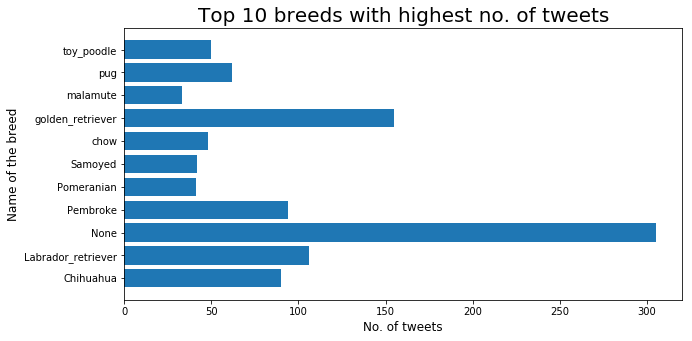

```python
labels = archive_df_clean.breed.value_counts().sort_values(ascending=False).head(11).index
values = archive_df_clean.breed.value_counts().sort_values(ascending=False).head(11).values
plt.figure(figsize = (10, 5))
plt.xlabel("No. of tweets",fontsize=12)
plt.ylabel("Name of the breed",fontsize=12)
plt.title("Top 10 breeds with highest no. of tweets",fontsize=20)
plt.barh(labels,values)
```

> **The highest number of tweets seem to be for Golden Retriever (ignoring the tweets which don't have the breed set).**

### Insight 4: Which are the top 10 breeds that have the most favorited tweets?

```python
archive_df_clean.groupby('breed')['favorite_count'].sum().sort_values(ascending=False).head(11)
```

```
breed
None                  2164574
golden_retriever      1937855
Labrador_retriever    1265355
Pembroke              1038797
Chihuahua              743689
Samoyed                583906
French_bulldog         570921
chow                   446933
cocker_spaniel         407412
pug                    383817
toy_poodle             337270
Name: favorite_count, dtype: int64
```

### Visualization

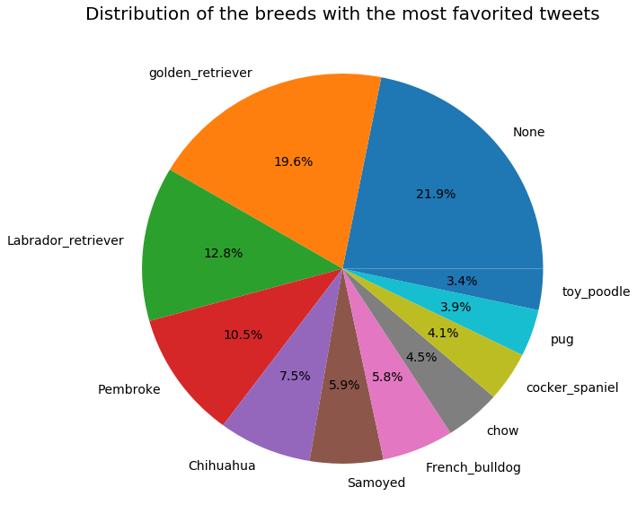

```python
labels = archive_df_clean.groupby('breed')['favorite_count'].sum().sort_values(ascending=False).head(11).index
values = archive_df_clean.groupby('breed')['favorite_count'].sum().sort_values(ascending=False).head(11).values

fig = plt.figure(figsize =(10, 10))
plt.title("Distribution of the breeds with the most favorited tweets",fontsize=20)
plt.pie(values, labels=labels,autopct='%1.1f%%', textprops={'fontsize': 14})

# show plot
plt.show()
```

> **Ignoring the 'None', the top 3 breeds to have the tweets with the most favorite count are Golden Retriever, Labrador_retriever and Pembroke.**

## Conclusion

**Data wrangling, analysis and visualization have been performed on the dataset containing the tweet archive of WeRateDogs. Some of the insights have been described above based on the analysis performed and the corresponding visualizations. Further analysis can be done for gaining additional insights since the data is in a cleaner format and is easier to work with.**